# p8105_hw1_lh3109

Lesi He

I’m an R Markdown document!

```r
library(tidyverse)
```

# Problem 1

```r
#creates a data frame
sample_df = tibble(
  #create 10 random normal variable
  norm_sample = rnorm(10),
  #logical vector indicating whether elements of the sample are greater than 0
  norm_samp_pos = norm_sample > 0,
  #character vector with length of 10
  character_vec = letters[1:10],
  #factor vectors with 3 factor levels
  factor_vec = factor(c("A", "C", "B","C","A", "C", "B","B","A", "A"), levels = c("A", "B", "C")),

  #try mean
  #x = mean(norm_samp_pos),
  #y = mean(character_vec),
  #z = mean(factor_vec)

  #try as.numeric
  #logical = as.numeric(norm_samp_pos),
  #character = as.numeric(character_vec),
  #factor = as.numeric(factor_vec)
)

sample_df
```

```
## # A tibble: 10 × 4
##    norm_sample norm_samp_pos character_vec factor_vec
##          <dbl> <lgl>         <chr>         <fct>
##  1      1.06   TRUE          a             A
##  2     -0.187  FALSE         b             C
##  3     -1.91   FALSE         c             B
##  4      1.15   TRUE          d             C
##  5      1.04   TRUE          e             A
##  6     -0.441  FALSE         f             C
##  7      1.21   TRUE          g             B
##  8     -0.0585 FALSE         h             B
##  9      0.126  TRUE          i             A
## 10     -0.463  FALSE         j             A
```

The mean function cannot be applied to the character vectors and factor vectors, while it can be applied to the logical variables.

After applying ‘as.numeric’ function to the logical, character, and factor variables, all of these variables change their data type. For logical variable, ‘TRUE’ is converted to 1 and ‘FALSE’ is converted to ‘0’. This makes sense as binary number can be used to demonstrate numbering scheme that only contains two possible outcomes. In the case of factor variables, the variables are converted to numbers based on the factor levels. It is reasonable as the vectors with same factor numbers are the same. Finally, the character variables all change to NA. This also make sense to me because the characters are all different and it will be hard to stratified or represented by digits. This function helps explain what happens when I try to take the mean.

# Problem 2

```r
#load dataset
data("penguins", package = "palmerpenguins")

#clean names
penguins = janitor::clean_names(penguins)
#find names of the variables
names(penguins)
```

```
## [1] "species"           "island"            "bill_length_mm"
## [4] "bill_depth_mm"     "flipper_length_mm" "body_mass_g"
## [7] "sex"               "year"
```

```r
#find number of rows
nrow(penguins)
```

```
## [1] 344
```

```r
#find number of columns
ncol(penguins)
```

```
## [1] 8
```

```r
#find the mean of flipper length, neglect NA value
mean(penguins$flipper_length_mm, na.rm = TRUE)
```

```
## [1] 200.9152
```

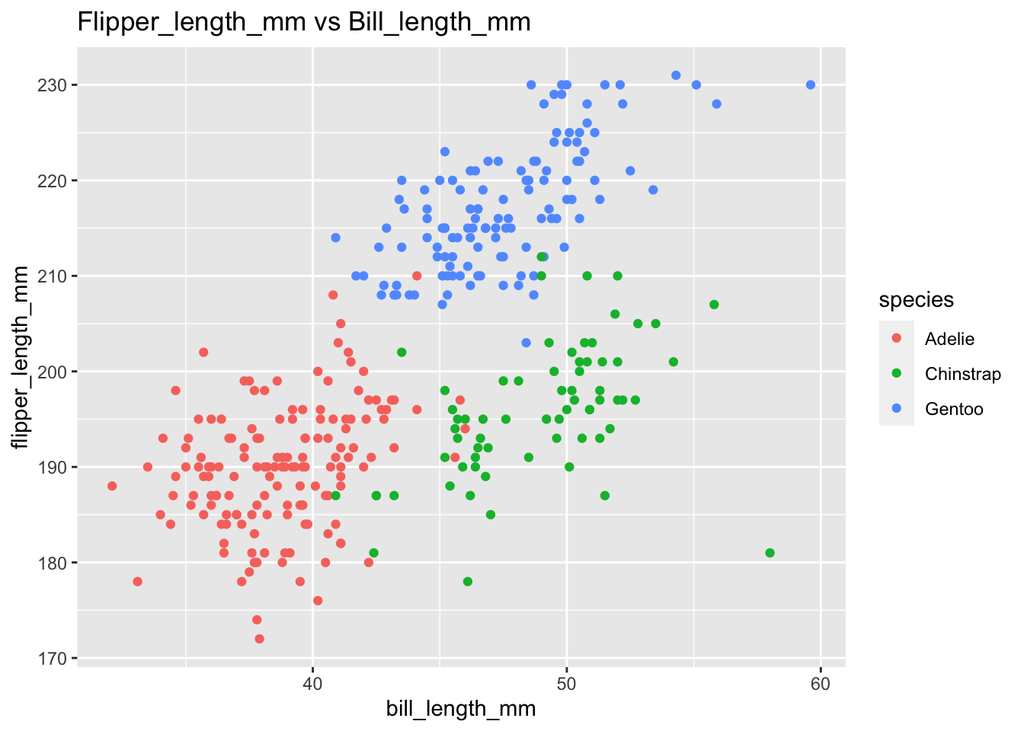

```r
#scatter plot of flipper_length_mm vs bill_length_mm
ggplot(penguins, aes(x = bill_length_mm, y = flipper_length_mm, color = species)) + geom_point() + labs(title = "Flipper_length_mm vs Bill_length_mm" )
```

```r
#save the plot
ggsave("Flipper_length_mm vs Bill_length_mm.png")
```

The “penguins” dataset contains different variables including species, island, bill length in mm, bill depth in mm, flipper length in mm, body mass in g, sex and year. There are 344 rows and 8 columns in this set. After neglecting the NA value in the column, the mean of the flipper length is 200.9152 mm.